# Covariates

```r
# Load packages
library(ggplot2)
library(dplyr)
```

**Goals**

When we started exploring multivariate models, our thinking was: “If x1 tells us something about y and x2 tells us something about y, then maybe x1 and x2 *combined* would tell us even more!”. In this spirit, you’ll explore the benefits & nuances of multivariate models.

## Getting started

The `CPS_2018` data set contains wage data collected by the Current Population Survey (CPS) in 2018. Using these data, we can explore the relationship between annual wages and marital status (married or single) among 18-34 year olds. The original codebook is [here](https://cps.ipums.org/cps/resources/codebooks/cpsmar18.pdf). And the data reflect how the government collects data regarding employment.

```r
# Load the data
CPS_2018 <- read.csv("https://www.macalester.edu/~ajohns24/data/CPS_2018.csv")

# Let's just look at 18 - 34 year olds and people that make under 250,000
CPS_2018 <- CPS_2018 %>%
  filter(age >= 18, age <= 34) %>%
  filter(wage < 250000)
```

We’ll start with a small model of `wage` vs `marital` status:

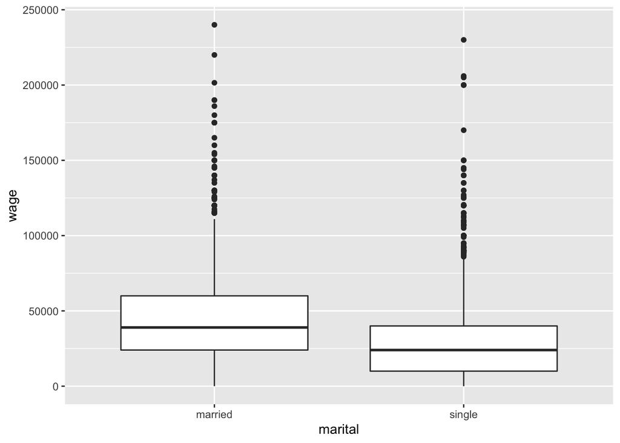

```r
# Visualize the relationship
ggplot(CPS_2018, aes(y = wage, x = marital)) +
  geom_boxplot()
```

```r
# Model the relationship
CPS_model_1 <- lm(wage ~ marital, CPS_2018)
summary(CPS_model_1)$coefficients
```

```
##                Estimate Std. Error   t value     Pr(>|t|)
## (Intercept)    46145.23    921.062  50.10002 0.000000e+00
## maritalsingle -17052.37   1127.177 -15.12839 5.636068e-50
```

**Class warm-up 1**

The `CPS_model_1` formula is: wage = 46145 - 17052 maritalsingle. Does this model provide evidence of workplace inequity for single workers?

**Class warm-up 2**

When exploring the relationship between response *y* and predictor *x*, there are often **covariates** for which we want to control.

1. In comparing the effectiveness of 2 different cold remedies, what are some potential covariates? How might we control for these when conducting an experiment to compare the remedies?
2. In investigating potential workplace inequity for single people, potential covariates include education, experience, and job type. How can we control for these covariates?

## Exercises

### Exercise 0: Hello!

What animal best represents how your week is going?

### Exercise 1: Controlling for age

Let’s start simple, by *controlling for* age (an imperfect measure of experience) in our model of wages by marital status. NOTE: Pause to think about the coefficients before answering the questions below.

```r
# Construct the model
CPS_model_2 <- lm(wage ~ marital + age, CPS_2018)
summary(CPS_model_2)$coefficients
```

```
##                 Estimate Std. Error   t value     Pr(>|t|)
## (Intercept)   -19595.948  3691.6998 -5.308110 1.184066e-07
## maritalsingle  -7500.146  1191.8526 -6.292847 3.545964e-10
## age             2213.869   120.7701 18.331265 2.035782e-71
```

1. Visualize this model by modifying the hint code in a new chunk. NOTE: Don’t get distracted by the last line. This is just making sure that the `geom_smooth` matches our model assumptions.

```r
# HINT CODE: don't change
ggplot(___, aes(y = ___, x = ___, color = ___)) +
  geom____(size = 0.1, alpha = 0.5) +
  geom_line(aes(y = CPS_model_2$fitted.values), size = 1.25)
```

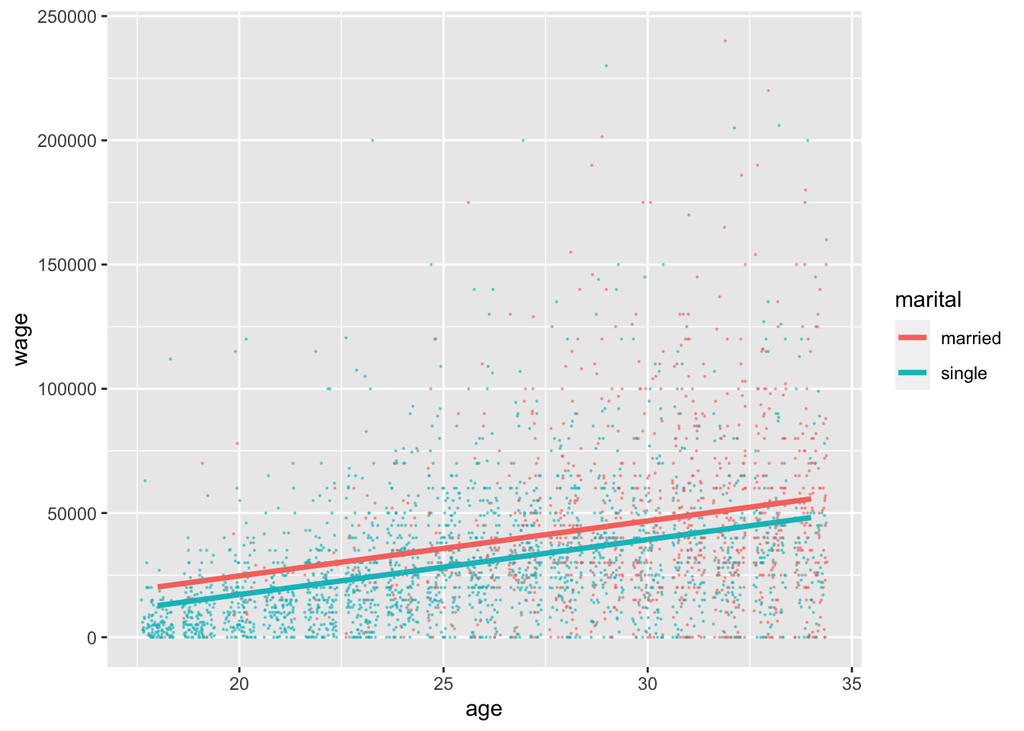

```r
# Your solution
ggplot(CPS_2018, aes(y = wage, x = age, color = marital)) +
  geom_jitter(size = 0.1, alpha = 0.5) + # jitter moves points that would be shadowing other points slightly
  geom_line(aes(y = CPS_model_2$fitted.values), size = 1.25)
```

2. Suppose two workers are the *same age*, but one is married and the other is single. According to the model, by how much do we expect the single worker’s wage to differ from the married worker’s wage?

About $\$7500$.

3. With your answer to part b in mind, which of the options below is another way to interpret the `maritalsingle` coefficient? On average…
   - Single workers make $7500 less than married workers.
   - > > > When controlling for (“holding constant”) age, single workers make $7500 less than married workers.

## Exercise 2: Controlling for more covariates

We’ve seen that among all workers, the wage gap of single vs married workers is $17,052. We also saw that age accounts for some of this difference. Let’s see what happens when we control for even more workforce covariates: model wages by marital status while controlling for `age` *and* years of `education`:

```r
CPS_model_3 <- lm(wage ~ marital + age + education, CPS_2018)
summary(CPS_model_3)$coefficients
```

```
##                 Estimate Std. Error    t value     Pr(>|t|)
## (Intercept)   -64898.607  4099.8737 -15.829416 2.254709e-54
## maritalsingle  -6478.094  1119.9345  -5.784351 7.988760e-09
## age             1676.796   116.3086  14.416777 1.102113e-45
## education       4285.259   207.2158  20.680173 3.209448e-89
```

1. Challenge: Construct a single visualization of the relationship among these 4 variables. Hot tip: Start by visualizing wage vs age, and step by step incorporate information about the other predictors.

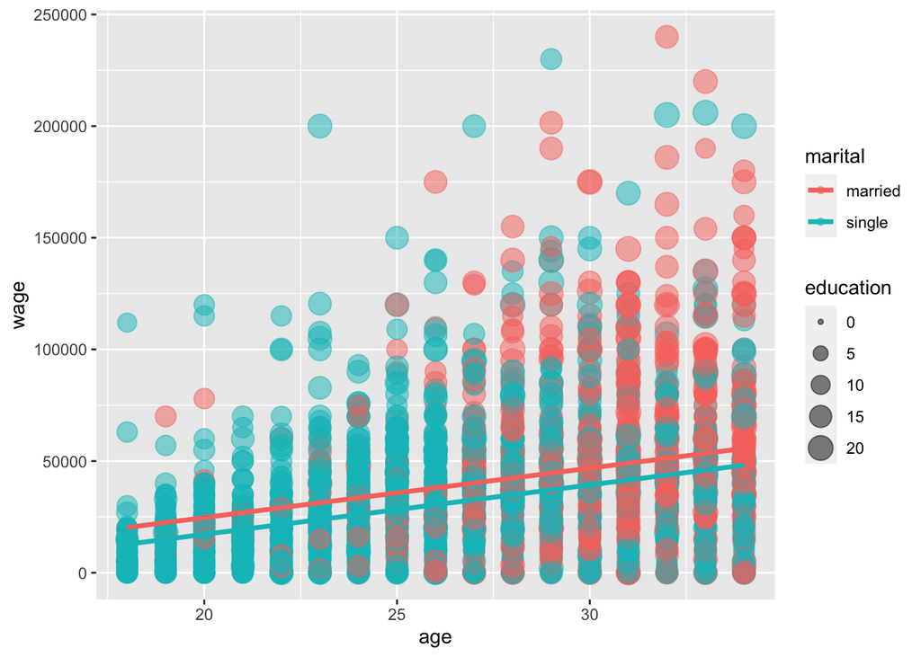

```r
ggplot(CPS_2018, aes(x = age, y = wage, color = marital, size = education)) +
  geom_point(alpha = 0.5) +
  geom_line(aes(y = CPS_model_2$fitted.values), size = 1.25)
```

2. With so many variables, this is a tough model to visualize. If you *had* to draw it, how would the model trend appear: 1 point, 2 points, 2 lines, 1 plane, or 2 planes? Explain your rationale. Hot tip: pay attention to whether your predictors are quantitative or categorical.

2 planes, one for each category.

3. Even if we can’t easily draw `CPS_model_3`, the coefficients contain the information we want! How can we interpret the education coefficient? On average…
   - Wages increase by $4285 for every extra year of education.
   - > > > When controlling for marital status and age, wages increase by $4285 for every extra year of education.
   - People with an education make $4285 more than those that don’t.
4. Which of the following is the best interpretation of the `maritalsingle` coefficient? On average…
   - > > > When controlling for age and education, single workers make $6478 less than married workers.
   - Single workers make $6478 less than married workers.

## Exercise 3: Even more covariates

Let’s control for another workforce covariate: model wages by marital status while controlling for `age` (quantitative), years of `education` (quantitative), *and* the `industry` in which one works (categorical):

```r
CPS_model_4 <- lm(wage ~ marital + age + education + industry, CPS_2018)
summary(CPS_model_4)$coefficients
```

```
##                                   Estimate Std. Error    t value     Pr(>|t|)
## (Intercept)                     -52498.857  7143.8481 -7.3488206 2.533275e-13
## maritalsingle                    -5892.842  1105.6898 -5.3295615 1.053631e-07
## age                               1493.360   116.1673 12.8552586 6.651441e-37
## education                         3911.117   243.0192 16.0938565 4.500408e-56
## industryconstruction              5659.082  6218.5649  0.9100302 3.628760e-01
## industryinstallation_production   1865.650  6109.2613  0.3053806 7.600964e-01
## industrymanagement                1476.884  6031.2901  0.2448704 8.065727e-01
## industryservice                  -7930.403  5945.6509 -1.3338158 1.823603e-01
## industrytransportation           -1084.176  6197.2462 -0.1749448 8.611342e-01
```

1. Challenge: Construct a single visualization of the relationship among these 5 variables. Hot tip: utilize a `facet_wrap(~ ___)` ala Activity 5.

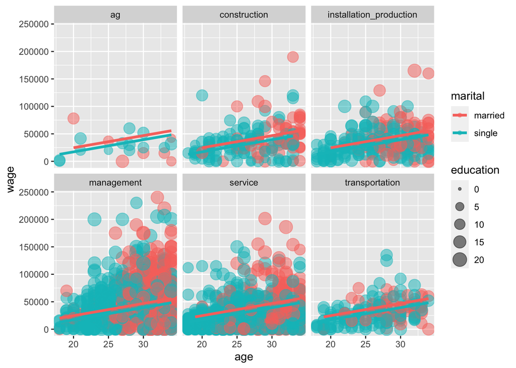

```r
ggplot(CPS_2018, aes(x = age, y = wage, color = marital, size = education)) +
  geom_point(alpha = 0.5) +
  geom_line(aes(y = CPS_model_2$fitted.values), size = 1.25) +
  facet_wrap(~industry)
```

2. If you *had* to draw it, how would the model trend appear: “z” points, “z” lines, or “z” planes? Specify “z” and explain your rationale.

12 planes, because we have two (mostly) smooth predictors, a binary categorical predictor, and a six-value categorical predictor.

3. When controlling for a worker’s age, marital status, and education, which industry tends to have the highest wages? The lowest?

Construction, because it has the highest coefficient. Service is the lowest.

4. Interpret the `maritalsingle` coefficient.

Being single decreases wage after controlling for the other factors by nearly 6000 dollars.

## Exercise 4: An even bigger model

Consider two people with the same age, education, industry, typical number of work hours, and health status. However, one is single and one is married.

1. Construct and use a new model to summarize the typical difference in the wages for these two people. Store this model as `CPS_model_5`.

```r
CPS_model_5 <- lm(wage ~ marital + age + education + industry + hours + health, CPS_2018)
summary(CPS_model_5)$coefficients
```

```
##                                    Estimate Std. Error     t value     Pr(>|t|)
## (Intercept)                     -64886.5747 6914.18198 -9.38456275 1.171028e-20
## maritalsingle                    -4992.7685 1061.84882 -4.70195794 2.687274e-06
## age                               1061.1410  115.83503  9.16079518 9.031462e-20
## education                         3443.7625  236.12723 14.58435151 1.128646e-46
## industryconstruction              5381.3857 5959.05620  0.90306007 3.665630e-01
## industryinstallation_production   2951.0372 5854.23981  0.50408547 6.142365e-01
## industrymanagement                5107.6364 5782.95334  0.88322283 3.771832e-01
## industryservice                  -3074.5127 5705.56537 -0.53886207 5.900201e-01
## industrytransportation            -207.3439 5940.02074 -0.03490626 9.721567e-01
## hours                              732.1340   43.72488 16.74410733 2.340115e-60
## healthfair                       -7407.7981 2901.71339 -2.55290483 1.072955e-02
## healthgood                       -2470.8096 1259.44276 -1.96182766 4.987035e-02
## healthpoor                       -9086.9110 7657.43781 -1.18667774 2.354441e-01
## healthvery_good                    292.5278 1020.89213  0.28654136 7.744823e-01
```

2. After controlling for all of these workforce covariates, do you still find the remaining wage gap for single vs married people to be meaningfully “large”? Can you think of any remaining factors that might explain part of this remaining gap? Or do you think we’ve found evidence of inequitable wage practices for single vs married workers?

Nearly 5000 is still a meaningful amount change from baseline. There are few other categories present that are as strong. There are only two other categories, sex, disability and citizenship remaining, and they may be strongly linked to marriage which would account for its effect. Location is not a variable, and may also have an effect.

## Exercise 5: Model comparison & selection

Take two workers, one of which is married and the other of which is single. The models above provided the following insights into the typical difference in wages for these two groups:

| Model | Assume the two people have the same… | Wage difference | R<sup>2</sup> |
| --- | --- | --- | --- |
| `CPS_model_1` | NA | -$17,052 | 0.067 |
| `CPS_model_2` | age | -$7,500 | 0.157 |
| `CPS_model_3` | age, education | -$6,478 | 0.257 |
| `CPS_model_4` | age, education, industry | -$5,893 | 0.280 |
| `CPS_model_5` | age, education, industry, hours, health | -$4,993 | 0.341 |

1. Though this won’t always be the case in every analysis, notice that the `marital` coefficient got closer and closer to 0 as we included more covariates in our model. Explain the significance of this phenomenon in the context of our analysis - what does it *mean*?

It means that marital status is correlated to these covariates, ie that adding the covariates as predictors implied a marital result, diminishing the predictive value of marital status to the model.

2. We’ve built several models here – and there are dozens more that we could build but haven’t. Amongst so many options, it’s important to anchor our analysis and model building in our research goals. With respect to each possible goal below, explain which of our 5 models would be best.
   1. Our goal is to maximize our understanding of why wages vary from person to person. Maximize the number of variables to find the strongest predictor.
   2. Our goal is to understand the relationship between wages and marital status, ignoring all other possible factors in wages. Maximize the number of variables to find the true weight of marital status.
   3. Our goal is to understand the relationship between wages and marital status while controlling for a person’s age and education. Use only wages, marital status, age and education as predictors.
   4. Our goal is to maximize our understanding of why wages vary from person to person *while keeping our model as simple as possible*. Use health, marital status, and industry, as they have the largest effect in the biggest model.
3. Consider goal iv. Explain why you think *simplicity* can be a good model feature. Simplicity means that less data needs to be collected for higher confidence. Simpliciy makes the model easier to interpret.

## Exercise 6: Data drill + curiosity

1. We took a very narrow look at the wage data set. What other curiosities do you have about these data? Identify one new question of interest, and explore this question using the data. It can be a simple question and answered in 1 line / 1 set of lines of R code, so long as it’s not explored elsewhere in this activity.
2. Use `dplyr` tools to complete the data drill below. (There are some structural hints in the online manual version!)

```r
# Load and use the complete CPS_2018 data
CPS_2018 <- read.csv("https://www.macalester.edu/~ajohns24/data/CPS_2018.csv")

# What are the mean and median wage?
CPS_2018 %>%
  summarize(mean(wage), median(wage))
```

```
##   mean(wage) median(wage)
## 1   51330.61        38000
```

```r
# What is the median wage in each industry?
CPS_2018 %>%
  group_by(industry) %>%
  summarize(mean(wage), median(wage))
```

```
## # A tibble: 6 x 3
##   industry                `mean(wage)` `median(wage)`
## * <chr>                          <dbl>          <dbl>
## 1 ag                            32115.          30000
## 2 construction                  44754.          36000
## 3 installation_production       46011.          38000
## 4 management                    70917.          55000
## 5 service                       34508.          25000
## 6 transportation                38147.          30000
```

```r
# How many workers fall into each health group?
CPS_2018 %>%
  group_by(health) %>%
  count
```

```
## # A tibble: 5 x 2
## # Groups:   health [5]
##   health        n
##   <chr>     <int>
## 1 excellent  3162
## 2 fair        537
## 3 good       2610
## 4 poor         80
## 5 very_good  3611
```

```r
# Obtain a dataset of workers aged 18 to 22 that are in good health
# Show just the first 6 rows
# Hint: <= is "less than or equal to"
CPS_2018 %>%
  filter(17 < age, age < 23) %>%
  head(6)
```

```
##    wage age education    sex marital                industry    health hours
## 1 33000  19        16 female  single              management very_good    40
## 2  4000  20        12   male  single installation_production very_good    54
## 3  8400  19        12   male  single                 service excellent    20
## 4 19250  22        13 female  single                 service excellent    40
## 5 18200  21        16 female  single                 service excellent    25
## 6 14000  19        11 female  single                 service excellent    40
##   citizenship disability education_level
## 1         yes         no       bachelors
## 2         yes         no              HS
## 3         yes         no              HS
## 4         yes         no    some_college
## 5         yes         no       bachelors
## 6         yes         no         some_HS
```

```r
# In one set of lines, calculate the median age (in years) amongst workers in excellent health
# See online manual for structural hint
CPS_2018 %>%
  filter(health == "excellent") %>%
  summarize(median(age))
```

```
##   median(age)
## 1          38
```

```r
# In one set of lines, calculate the median age (in MONTHS) amongst workers in excellent health
# See online manual for structural hint
CPS_2018 %>%
  filter(health == "excellent") %>%
  summarize(median(age * 12))
```

```
##   median(age * 12)
## 1              456
```